## Twitter Sentiment Analysis - Data Preprocessing & Naive Bayes

# Setup

Import libraries and mount your drive

Link to the Dataset: [Click Here](https://drive.google.com/drive/folders/1BDQIz6EbLxR64c_nUT0zYIzoA-tu7as7?usp=share_link)

```python
import string
import sklearn
import matplotlib.pyplot as plt
%matplotlib inline
import pandas as pd
import numpy as np
import math
import os
from matplotlib import pyplot as plt
from sklearn.linear_model import LogisticRegression
from sklearn.metrics import confusion_matrix, f1_score, accuracy_score
from sklearn.model_selection import train_test_split
from sklearn.linear_model import LogisticRegression
from sklearn.naive_bayes import MultinomialNB
from sklearn.model_selection import GridSearchCV
import re
from sklearn.feature_extraction.text import TfidfVectorizer
import numpy as np
from sklearn.metrics import classification_report
```

```python
from google.colab import drive
drive.mount('/content/drive')
```

# Read Dataset

Replace the paths with your paths to read the files

```python
#extract files
tr = pd.read_csv('/content/drive/MyDrive/PA3_dataset/train.csv')
ts = pd.read_csv('/content/drive/MyDrive/PA3_dataset/test.csv')
stop = pd.read_table('/content/drive/MyDrive/PA3_dataset/stop_words.txt',header=None)[0]
```

```python
#separate tweets from files
tr_tweets = tr["Tweet"]
ts_tweets = ts["Tweet"]
tr_labels = tr["Sentiment"]
ts_labels = ts["Sentiment"]
tr_size = len(tr_tweets)
ts_size = len(ts_tweets)
```

# Data Preprocessing

Clean your data to remove unwanted symbols. </br> The following methods are helpful: </br>

- [.casefold()](https://www.w3schools.com/python/ref_string_casefold.asp)
- [.lstrip()](https://www.w3schools.com/python/ref_string_lstrip.asp)
- [re.sub()](https://www.w3schools.com/python/python_regex.asp)
- [.rstrip()](https://www.w3schools.com/python/ref_string_rstrip.asp)
- [.replace](https://www.w3schools.com/python/ref_string_replace.asp)

*Note: You may use other functions for processing but these should be enough*

```python
#Part 1 - Data Preprocessing
for indx in range(tr_size):   # pre-process training data
  tr_tweets[indx] = " ".join(((                        #removing whitespaces
        re.sub(r'[^\w\s]', '', (                       #remove punctuation and symbols
            re.sub(r'\d+', '', (                       #removing digits
                re.sub('\n', '', (                     #removing next line symbols
                    re.sub('http[^\s]+','',(           #removing hyperlinks
                        re.sub('@[^\s]+','',(          #remove usernames
                            tr_tweets[indx].casefold() #convert strings to lowercase
                            ))))))))))).strip()).split())

  sentence = tr_tweets[indx].split()
  for word in stop: #remove stop words
    if word in sentence:
      sentence = [i for i in sentence if i != word]
  tr_tweets[indx] = (" ").join(sentence)

for indx in range(ts_size): # pre-process testing data
    ts_tweets[indx] = " ".join(((                        #removing whitespaces
        re.sub(r'[^\w\s]', '', (                       #remove punctuation and symbols
            re.sub(r'\d+', '', (                       #removing digits
                re.sub('\n', '', (                     #removing next line symbols
                    re.sub('http[^\s]+','',(           #removing hyperlinks
                        re.sub('@[^\s]+','',(          #remove usernames
                            ts_tweets[indx].casefold() #convert strings to lowercase
                            ))))))))))).strip()).split())
    sentence = ts_tweets[indx].split()
    for word in stop: #remove stop words
      if word in sentence:
        sentence = [i for i in sentence if i != word]
    ts_tweets[indx] = (" ").join(sentence)
```

# Bag of Words

```python
#Part 2 - Bag Of Words
# Extract vocab from training data set
vocab_list = []
for indx in range(tr_size):
  # read tweet
  #tr_tweets[indx] = tr_tweets[indx].split()
  # append words from each tweet to vocab_list
  # make sure words don't get repeated
  # {Code Here}
  for item in tr_tweets[indx].split():
    if not item in vocab_list:
        vocab_list.append(item)
  vocab_list.sort()

# Create Bag of Words Matrix of size (number of tweets in training data, size of vocabulary)
# each row is a tweet and each column is a word
matrix = np.zeros(((tr_size, len(vocab_list))))

# Populate BoW
# Go through the words in each tweet
# for each word append the count of the matrix at relevant position
# {Code Here}
for twtindx in range(tr_size):
    for word in tr_tweets[twtindx].split():
      matrix[twtindx][vocab_list.index(word)] = tr_tweets[twtindx].count(word)
```

```python
matrix
```

```
array([[0., 0., 0., ..., 0., 0., 0.],
       [0., 0., 0., ..., 0., 0., 0.],
       [0., 0., 0., ..., 0., 0., 0.],
       ...,
       [0., 0., 0., ..., 0., 0., 0.],
       [0., 0., 0., ..., 0., 0., 0.],
       [0., 0., 0., ..., 0., 0., 0.]])
```

```python
len(vocab_list)
```

```
7593
```

# Implement Naive Bayes

- Step 01: Create a dictionary 'count' to store the number of times a word occurs in each class (positive, negative, neutral). You can do this by using the matrix. For each tweet use the index to access the actual label from tr_labels. </br> The dictionary will have the following structure: </br> $count[word] = [positive, negative, neutral]$ </br> Example:  
  $count['to'] = [5,10,12]$

```python
count = {}
# {Code Here}
for item in vocab_list:
  count[item] = [0 , 0 , 0]

l = list(zip(*np.where(matrix == 1)))
l = sorted(l , key=lambda k: [k[1], k[0]])
tmp = 0
for item in l:
    tweet_indx,vocab_indx = item
    if tr_labels[tweet_indx] == 'positive':
      count[vocab_list[vocab_indx]] = np.add(count[vocab_list[vocab_indx]], [1,0,0])
    elif tr_labels[tweet_indx] == 'negative':
      count[vocab_list[vocab_indx]] = np.add(count[vocab_list[vocab_indx]], [0,1,0])
    elif tr_labels[tweet_indx] == 'neutral':
      count[vocab_list[vocab_indx]] = np.add(count[vocab_list[vocab_indx]], [0,0,1])
```

```python
count['moved']
```

```
array([ 2, 10,  1])
```

- Step 02: Find the prior probability of each class </br> To calculate the prior probability of a class calculate the ratio of </br> $N_{c}$ : $N_{t}$  
  where $N_{c}$ is the number of tweets belonging to the class and $N_{t}$ is the total number of tweets. </br> Store these in: </br> $prior = [positivePrior, negativePrior, neutralPrior]$

```python
# {Code Here}
prior = [
    len(np.where(tr_labels == 'positive')[0])/len(tr_labels),
         len(np.where(tr_labels == 'negative')[0])/len(tr_labels),
         len(np.where(tr_labels == 'neutral')[0])/len(tr_labels)
         ]
prior
```

```
[0.16188524590163936, 0.6181693989071039, 0.21994535519125682]
```

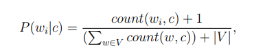

> Store inside a dictionary 'likelihoods' in the form: $likelihoods[word] = [positiveLikelihood, negativeLikelihood, neutralLikelihood]$ </br> For example : </br> $likelihoods['to']=[0.3,0.57,0.23]$

```python
likelihoods = {}
# {Code Here}
for item in vocab_list:
  likelihoods[item] = [0 , 0 , 0]

for item in count:
  likelihoods[item] = [
      ((count[item][0]+ 1)) / (sum(count[item])+len(vocab_list)), #Positive
      ((count[item][1]+ 1)) / (sum(count[item])+len(vocab_list)), #Negative
      ((count[item][2]+ 1)) / (sum(count[item])+len(vocab_list))  #Neutral
      ]
```

```python
likelihoods['moved']
```

```
[0.0003944254535892716, 0.0014462266631606626, 0.00026295030239284776]
```

```python
labelsMap = {"positive":0, "negative":1, "neutral":2}
```

# Predictions and Evaluation

Given a test data point, and the set of prior probabilities and likelihoods, we need to return the 'best' class c. </br>

1. We will create a vector 'prob' of length equal to the number of classes, 3. </br> $prob = [0,0,0]$
2. For each class c, we will initially add our prior probability to prob. </br>
3. Then for each word in the test data in our vocabulary, we will multiply the corresponding likelihood with prob. </br>
4. Finally, the maximum index of our 'prob' vector will be the predicted class for the test data point. </br>
5. Compare these to the actual labels to calculate F1_score, accuracy and confusion matrix. You can use scikit libraries for this. </br>

```python
# Predictions
actuals = []
predicted = []

for i,tweet in enumerate(ts_tweets):
  actuals.append(labelsMap[ts_labels[i]])
  prob = [0 , 0 , 0]
  prob = np.add(prob, prior)
  tweet = tweet.split();
  for item in tweet:
    if vocab_list.count(item) == 1:
      prob = np.multiply(prob , likelihoods[item])
  predicted.append(np.argmax(prob))

predicted = np.array(predicted)
actuals = np.array(actuals)
```

```python
# Evaluation
# {Code Here}
```

```python
accuracy_score(actuals,predicted)
```

```
0.6489071038251366
```

```python
f1_score(actuals,predicted, average='weighted')
```

```
0.5312948044557574
```

```python
cfm = confusion_matrix(actuals,predicted)
print(cfm)
```

```
[[ 18 218   3]
 [  0 921   3]
 [  1 289  11]]
```

# Scikit Implementation of Naive Bayes

```python
matrixts = np.zeros(((ts_size, len(vocab_list))))
for twtindx in range(ts_size):
    for word in ts_tweets[twtindx].split():
      if vocab_list.count(word) == 1:
        matrixts[twtindx][vocab_list.index(word)] = ts_tweets[twtindx].count(word)

actualstr = []

for i,tweet in enumerate(tr_tweets):
  actualstr.append(labelsMap[tr_labels[i]])
```

```python
# {Code Here}
from sklearn.datasets import make_classification
from sklearn.linear_model import LogisticRegression
from sklearn.multiclass import OneVsRestClassifier
# define dataset
# define model
model = MultinomialNB()
# define the ovr strategy
ovr = OneVsRestClassifier(model)
# fit model
ovr.fit(matrix, actualstr)
# make predictions
yhat = ovr.predict(matrixts)
```

```python
accuracy_score(actuals,yhat)
```

```
0.7629781420765027
```

```python
f1_score(actuals,yhat, average='weighted')
```

```
0.738466414548966
```